# Highschool and Beyond survey analysis

Joshua Xavier

2026-09-14

# 1 Data set and Practical Questions

## 1.1 Description of data set

| Variable | Type | Description |
| --- | --- | --- |
| id | Numerical (identifying) | Student id number |
| write | Numerical (response candidate, continuous) | Writing test score |
| read | Numerical (explanatory) | Reading test score |
| math | Numerical (explanatory) | Math test score |
| science | Numerical (explanatory) | Science test score |
| socst | Numerical (explanatory) | Social studies test score |
| gender | Categorical (2 levels) | Student gender |
| race | Categorical (4 levels) | Student race/ethnicity |
| ses | Categorical (3 levels) | Socioeconomic status: low/middle/high |
| schtyp | Categorical (2 levels) | School type: public/private |
| prog | Categorical (3 levels) | Program type: general/academic/vocational |

The data set used in this project is the “hsb2” data set, an acronym for “high school and beyond”. The data set contains 200 randomly selected observations from the “High School and Beyond” survey, which was conducted by the National Center for Education Statistics and polled seniors in high school. The dataset uses 11 total variables, 1 identifying variable (id), 5 numerical variables, including the response variable write, and 5 categorical variables.

The dataset contains enough information to investigate these questions because it includes socioeconomic status, academic program, demographic characteristics, and multiple standardized test scores for 200 students, with 11 variables. This allows us to compare academic preformance across different groups and use statistical methods to determine whether a meaningful relationships exist.

## 1.2 Practical Question

Using this data set, we hope to find whether a students socioeconomic status and academic program relate with their preformance in highschool. Analytically, we would like to see whether there is a statistically significant relationship between socioeconomic status and a students standardized writing scores. we would also like to see whether writing scores can be predicted using socioeconomic status or other test scores.

# 2 Data Analysis

First we explore the pairwise association between the numerical variables in the data set.

## 2.1 Pairwise Scatter Plot

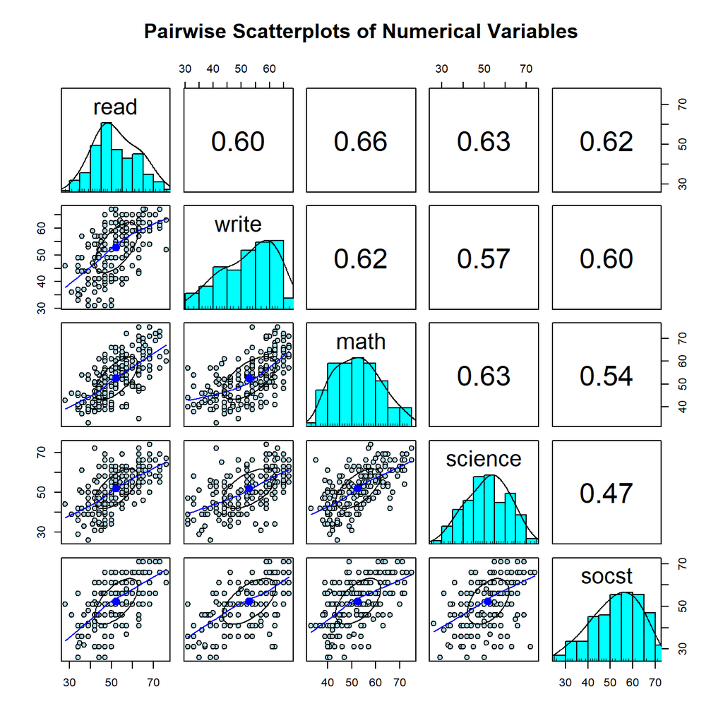

Figure 1: Pairwise scatter plot.

The five variables all show a positive relationship with each other. In general, students who scored higher in one subject also scored higher in the others. Reading and math had the strongest relationship at 0.66, while science and social studies had the weakest at 0.47. It is also worth mentioning reading had a particularly strong relationship with the other subjects.

The points follow a fairly straight upward pattern, so a linear model appears to be appropriate for predicting writing scores from reading scores.

If a transformation is needed, we would transform the response variable. This is because the Box Cox transformation helps fix stabilize variance, normalize residuals, and improves linearity, which are tied to the response variable in a linear regression model.

# 3 Fitting SLR to Data

We use parametric and bootstrap regression models to assess the association between writing score and reading score

## 3.1 Scatter Plot

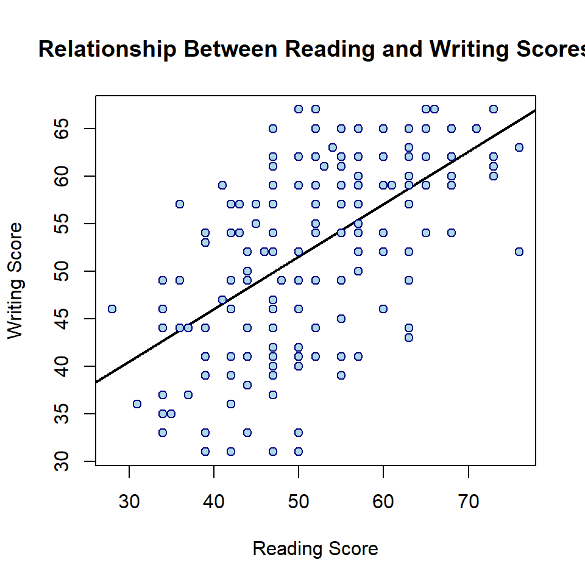

Figure 2: Scatter plot between reading and writing scores.

Figure 2 shows a positive relationship between writing test scored and reading test scores.

## 3.2 Parametric Simple Linear Regression

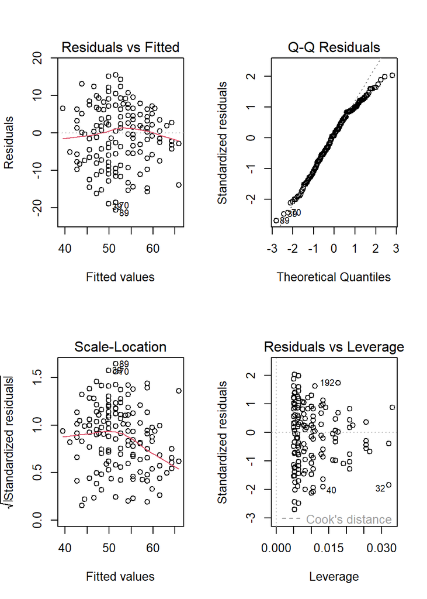

Coefficient estimates (R² = 0.356)

| term | estimate | std.error | statistic | p.value |
| --- | --- | --- | --- | --- |
| (Intercept) | 23.9594 | 2.8057 | 8.5394 | 0 |
| reading | 0.5517 | 0.0527 | 10.4652 | 0 |

### 3.2.1 Residual Plots

We can see from the residual plots:

- The Residuals Vs Fitted plot has points randomly scattered points, but a bent line possibly indicating a linearity violation.
- The Scale-Location plot, similar to the vs fitted plot, has points scattered randomly, but a bent line possibly indicating the constant variance assumption is not satisfied
- The QQ Residual plot shows departures from the red line near both tails, suggesting a violation of the normality assumption.
- The Residuals Vs Leverage plot indicates that there are no serious outliers,

From the SLR model, we see a positive relationship between reading and writing scores, with a reading coefficient of 0.55. This means that for every one point increase in reading score, the predicted writing score increases by about 0.55 points. The R² value is 0.356, meaning that reading scores explain about 35.6% of the variation in writing scores. The p-value for reading is less than 2.2 × 10⁻¹⁶, providing very strong evidence of a statistically significant relationship between reading and writing scores.

## 3.3 Box Cox Transformation

Since the residual plots show possible violations, we check if transformations would fix the problems to a meaningfull degree.

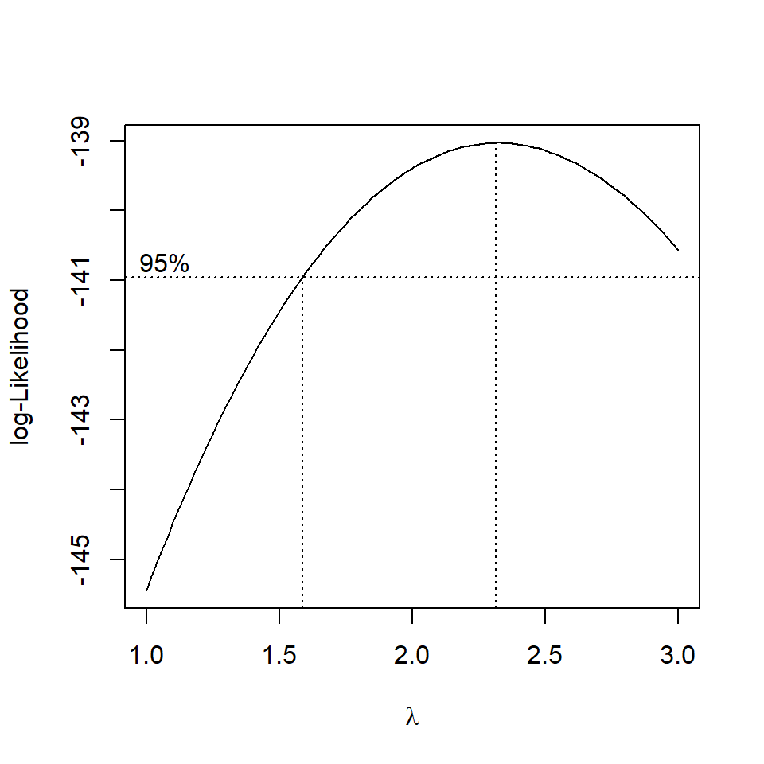

Box-Cox transformation.

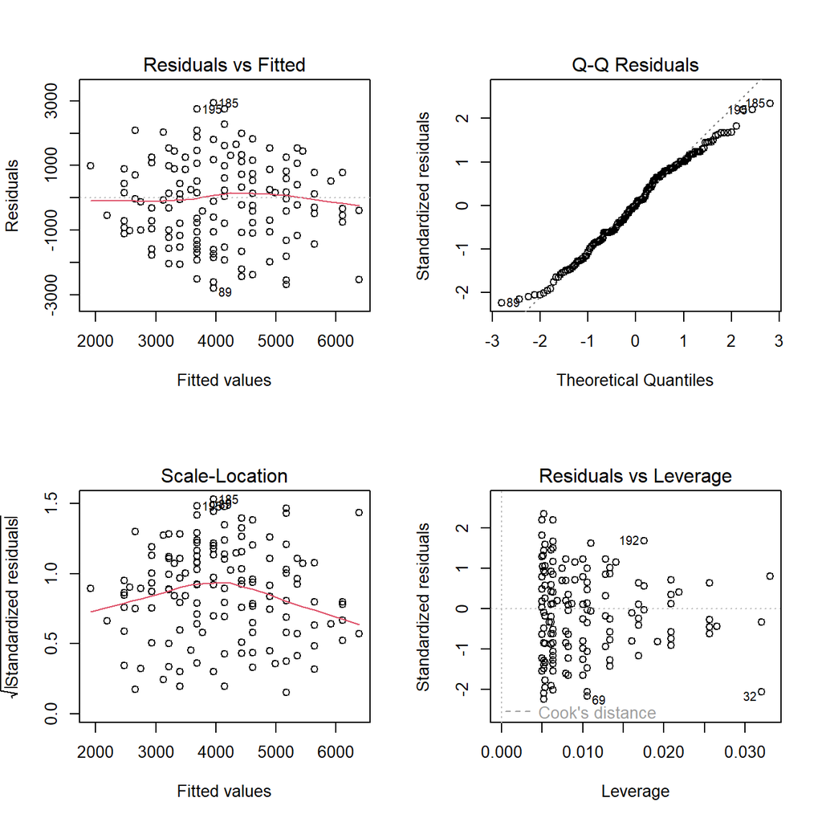

Box-Cox transformed SLR.

| Model | R_squared | Shapiro_p |
| --- | --- | --- |
| write ~ read (raw) | 0.3561 | 0.0072 |
| Box-Cox transformed (lambda = 2.3) | 0.3690 | 0.0467 |

## 3.4 Bootstrap confidence intervals

95% Bootstrap Confidence Intervals for Regression Coefficients

|  | Intercept | Reading |
| --- | --- | --- |
| **2.5%** | 18.85 | 0.4598 |
| **97.5%** | 29.12 | 0.6432 |